# 10. 반응표면분석

## 10.01. 반응표면분석

- 실제 실험된 실험조건을 비교하여 최적조건을 찾는 것 보다는 고려된 계량인자들의 관심영역 전체에서 최적조건을 구하고자 하는 경우가 더 빈번

### 반응표면분석 3단계

- **0단계 : 2수준 일부실시법에 의해서 반응변수에 영향을 미칠 것이라고 기대되는 많은 인자 중에서 핵심인자를 선별**
  - **0단계에서 2수준 일부실시법에 의해서 핵심인자가 선별된 후에는 선별된 인자의 최적조건 근처 영역으로 이동하기 위하여 1단계를 수행**
- **1단계 : 선별된 핵심인자에 대한 축차적인 실험계획 (중심점을 갖는 2수준 요인배치법)과 분석에 의해 최적조건 근처의 설명변수의 영역으로 이동 (최대경사법)**
  - 1단계에서는 반응표면을 일차모형으로 근사시키고, 2수준 요인배치법 (또는 부분실시법)과 독깁변수의 관심범위 중앙에서 실험을 실시하고, 최대경사법을 이용하여 실험점의 이동방향을 결정
  - 최적조건 근처에 닿기까지 여러 번 수행
  - 1단계를 통해서, 계량인자의 최적조건 근처 영역으로 이동한 후 2단게 수행
- **2단계 : 최적조건 근처에서 이차모형을 가정하고, 효율적인 실험계획인 중심합성계획으로 실험 실시, 실험자료의 분석을 통해서 관심영역에서 반응변수의 예측치를 최적화 하는 계량인자의 최적조건을 찾고 재현성을 확인**
  - **중심합성계획 (CCD, central composite design)에 따라 실험자료를 얻은 다음, 관심영역에 임의로 주어진 독립변수의 값에 대응하는 반응변수의 평균을 예측하고,**

    **반응변수의 예측치를 최적으로 하는 계량인자의 최적조건을 찾고,**

    **최적조건하에서 재현성을 검토**
- 반응변수 수율 $y$와 독립변수 반응시간 $t$, 반응온도 $T$간의 함수관계를 나타내기 위하여 관심영역에 있는 임의의 독립변수의 값 $t, T$에서 반응변수의 모평균 $\eta[=E(y)]$를

  $$\eta = f(t, T)$$라 할 때, 3차원 그래프로 그린 그림을 반응표면이라고 한다
  - **계량인자인 반응시간 $t$, 반응온도 $T$의 관심영역에서 평균수율을 최대로 하는 최적화 조건을 $(t*, T*)$라 하면,**

    **반응시간 $t$, 반응온도 $T$가 최적조건인 $(t*, T*)$를 벗어나는 경우에는 평균수율 $\eta$가 작아져야 하므로**

    **$f$는 곡선효과를 가져야하고, 곡선효과를 갖는 간단한 함수가 이차함수이므로, 반응표면분석에서는 최적조건 근처의 모형으로 흔히 이차모형을 가정**
  - 함수 $f$가 반응시간 $t$, 반응온도 $T$의 이차함수인 경우, 즉, 반응표면모형이 이차모형인 경우 네 가지 형태의 대표적인 반응표면이 존재
  - **최적조건이 되는 실험조건은 이차반응함수인 $f$를 각각의 독립변수에 대해 편미분해서 0이 되도록 하는 값 $\rightarrow$ 정상점 (stationary point)**
    - **(a)는 산 모양으로 정상점에서 최댓값을 가짐**
      - 정상점에 가까이 갈수록 등고선상의 $\eta$값이 증가

    **(b)는 사발 모양으로 최솟값을 가짐** - 정상점에 가까이 갈수록 등고선상의 $\eta$값이 감소

    **(c)는 말 안장모양의 안정점(saddle point)를 가지며** - 정상점에 가까이 갈수록, 한쪽에서는 증가, 한쪽에서는 감소하는 안장점 **(d)는 올라가는 능선의 모양으로 관심영역에서 정상점이 존재하지 않음**

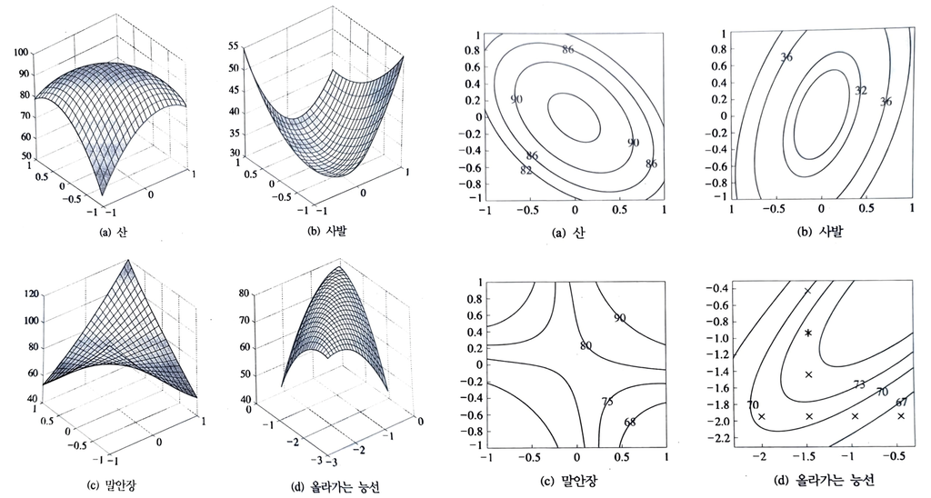

## 11.02. 최대경사법

- 1단계의 목표는 선ㅌ낵된 핵심인자에 대한 축차적인 실험계획과 데이터의 분석을 통해 최적조건 근처의 설명변수 영역으로 최대한 빨리 이동하는 것
- 초기단계의 모형은 선별된 핵심인자에 대해 일차(선형)모형을 가정
- 공정수율 $y$를 높이려고 하는 공정조건을 찾는 화학공정의 예에서 실험자가 관심 있는 반응시간 $t$의 범위가 (30분 ~ 40분)이고, 반응온도 $T$의 범위가 (160 ~ 180)일 때,

  이 경우 반응표면방법(response surface method)에서는 관심영역에서 독립변수의 값이 -1에서 1 사이의 값이 되도록 선형변환한 변수인 '부호화한 변수'를 이용하여 반응표면을 표현

  부호화난 변수 $x_1, x_2$는 다음과 같이 원 변수인 $t$와 $T$의 선형식으로 표현

  $$x_1 = \frac{t-35}{5},\;\;\;x_2=\frac{T-170}{10}$$
- 1단계에서는 관심영역의 중심점인 (0, 0)에서 여러 번 실험을 실시

  중심점에서 공정수율이 꼭지점에서의 공정수율과 크게 다른지 (일차모형의 적합 결여) 검토하기 위함

  네 군데 꼭지점에서 평균과 중심점에서의 평균을 비교해, 그 차이가 아주 크다면 $t, T$와 $y$간 선형이 아닌 곡선효과가 있다고 의심
- $t$와 $y$, $T$와 $y$간에는 선형모형이 적절

```r
library(tidyverse)
library(tidymodels)
```

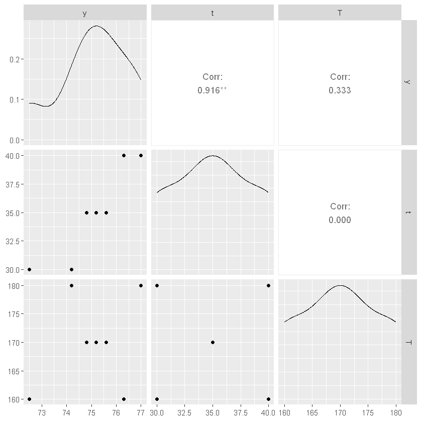

```r
y <- c(72.5, 74.2, 76.3, 77, 74.8, 75.6, 75.2)
t <- c(30, 30, 40, 40, 35, 35, 35)
T <- c(160, 180, 160, 180 ,170 ,170, 170)
dat <- data.frame(y, t, T)

GGally::ggpairs(dat)
```

$y = 75.0857 + 1.65x_1 + 0.6x_2$

```r
c.t <- (t-35) / 5
c.T <- (T - 170)/10
reduced.mod <- lm(y ~ c.t + c.T)
tidy(reduced.mod)
```

A tibble: 3 × 5

| term <chr> | estimate <dbl> | std.error <dbl> | statistic <dbl> | p.value <dbl> |
| --- | --- | --- | --- | --- |
| (Intercept) | 75.08571 | 0.1510170 | 497.200539 | 9.817777e-11 |
| c.t | 1.65000 | 0.1997767 | 8.259223 | 1.172464e-03 |
| c.T | 0.60000 | 0.1997767 | 3.003354 | 3.981013e-02 |

$y = 75.0857+1.65x_1 + 0.6x_2-0.25x_1 x_2$

```r
full.mod <- lm(y ~ c.t*c.T)
tidy(full.mod)
```

A tibble: 4 × 5

| term <chr> | estimate <dbl> | std.error <dbl> | statistic <dbl> | p.value <dbl> |
| --- | --- | --- | --- | --- |
| (Intercept) | 75.08571 | 0.1360272 | 551.990409 | 1.311206e-08 |
| c.t | 1.65000 | 0.1799471 | 9.169362 | 2.742607e-03 |
| c.T | 0.60000 | 0.1799471 | 3.334314 | 4.457572e-02 |
| c.t:c.T | -0.25000 | 0.1799471 | -1.389297 | 2.589030e-01 |

- **두 모형 비교** : 추가된 항이 유의하지 않으므로, 선형모형으로 충분함

```r
anova(reduced.mod, full.mod)
```

A anova: 2 × 6

|  | Res.Df <dbl> | RSS <dbl> | Df <dbl> | Sum of Sq <dbl> | F <dbl> | Pr(>F) <dbl> |
| --- | --- | --- | --- | --- | --- | --- |
| 1 | 4 | 0.6385714 | NA | NA | NA | NA |
| 2 | 3 | 0.3885714 | 1 | 0.25 | 1.930147 | 0.258903 |

- 선형모형에 대한 오차항 가정 확인
  - 오차 정규성 확인

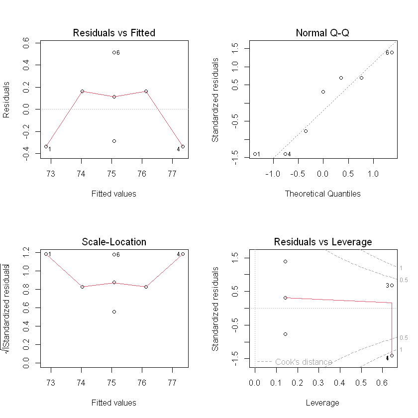

```r
par(mfrow = c(2, 2))
plot(reduced.mod)
par(mfrow = c(1, 1))
```

  **최적조건은 현 실험영역의 범위 밖에 있음**

  **$\rightarrow$ 최적조건을 찾기 위하여, 새로운 실험과 실험점 필요**

  **$\rightarrow$ 최대경사법 사용**

#### 최대경사법

- **반응값이 최대 증가를 보이는 방향, 최대 상승경로를 따라 실험점을 이동하는 방법**
- **부호화된 변수의 중심점인 (0, 0)을 기준으로 최대 상승경로를 따라 일정 간격씩 이동하면서 실험을 실시하다가**

  **최대상승경로는 $x_1$방향으로 1.65단위 증가할 때마다, $x_2$방향으로 0.6단위 증가하는 방향이므로, 최대상승경로의 기울기는 $0.6/1.65=0.364$**

  **즉, 중심점 (0, 0)을 기준으로 $x_1$방향으로 1단위 증가할 때, $x_2$방향으로는 0.364 증가**

  **($\Delta=(1, 0.364)$)**
- 반응값인 평균수율을 가장 빨리 증가시킬 것으로 기대되는 다음 실험점인 ($x_1, x_2$)의 값은 $\Delta$이고, 그 다음 실험점들의 후보는 2$\Delta$, 3$\Delta$, $\dots$
- 현재의 위치가 중앙점인 $(t, T)=(35, 170)$이라면,

  다음 실험점은 $\Delta$만큼 이동한 $(t, T) = (40, 173.6)$

  그 다음 실험점은 $\Delta$만큼 이동한 $(t, T) = (45, 177.3)$
- **각 실험점에서의 실험 결과 수율 $y$가 기존의 74.8 $\rightarrow$ 77.1 $\rightarrow$ 77.9로 증가하였고**,

  **네 번째 실험점이 82.47로 증가할 것으로 기대됬으나, 실제 실험결과는 이보다 작은 값이 나왔다면**

  **4회째 실험에서 멈추고, 그 이전의 3회째 실험조건 (50분, 180.9)에서의 반응치 80.9%가 최대 수율이 됨**

[output not shown]

- **1단계 실험은 이대로 종료 (여려 번 반복 가능)**

  **다음 단계 실험은 (50분, 180.9)를 중심으로 새로운 관심영역을 지정**

  **이후 중심합성계획을 이용하여, 실험점을 결정하고, 이차다항모형에 의한 반응표면분석으로 최적조건을 탐색**
- 독립변수가 3개 이상인 경우, 최대경사법의 최대 상승 경로도 앞에서 설명한 것과 같은 방법에 의해 결정

  $\Delta$를 결정할 때, $j$번째 원소와 값은 $\hat{\beta_j}/\hat{\beta_1}$

## 11.03. 이차 반응표면모형 적합을 위한 실험계획

- **최적조건 근처의 영역에서는 반응표면의 근사모형으로 독립변수들의 곡선효과가 고려된 이차모형을 가정**

#### 공정 예시

- 비닐봉지 접착력 $y$를 최대화하기 위해, 마감온도 $T$, 냉각온도 $C$, 폴리에틸렌 양 $P$가 반응값에 영향을 주는 계량인자일 때

  반응값 $y$에 대한 이차다항모형은

  $$y= \beta_0 + \sum^3_i \beta_i x_i + \sum^3_i \beta_{ii} x^2_i + \sum^2_{i=1} \sum^3_{j=i+1} \beta_{ij} x_i x_j + \epsilon$$
- **이차모형을 적합시키려면, 각 독립변수의 곡선효과를 추정해야 하므로, 각 요인에서 적어도 3수준씩 택하여 실험**

  따라서,$3^3$요인배치법이 유용하며, 총실험조건의 수는 $3^3=27$이고 각각의 실험조건에서 반복없이 1회 실험만 실시하는 경우 27회의 실험을 실시

  고려된 계량인자가 증가할수록, 총실험조건의 수는 기하급수적으로 증가 $\rightarrow$ 이차다항모형의 회귀계수를 효율적으로 추정할 수 있으면서 훨씬 적은 실험횟수를 필요로 하는 계획이 필요

  **일차모형을 위한 실험자료를 이미 가지고 있다면, 이차다항모형의 적합에 필요한 데이터를 더 가지면 됨**

  **$\rightarrow$ 즉, 중심점 (0, 0, 0)에서의 몇 개의 실험자료와 $2^3$요인배치에 의해 얻어진 실험자료를 가지고 있으므로, 이차다항모형의 적합에 꼭 필요한 새로운 실험점을 추가시키는 형태의 축차적인 실험계획이 더욱 실용적**

### 중심합성계획

- **$2^3$ 상자점 (factorial points), 중심점 (center points), 축점(axial points)로 구성**
  - 축점 $\alpha$는 구형실험계획 (spherical design)에서 결정

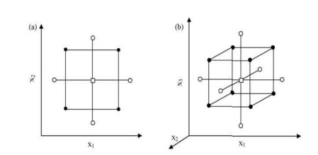

$$k = 2,\;\;\alpha = \sqrt{2}=1.414\;\;|\;\;k=3,\;\;\alpha=\sqrt{3}=1.732$$

- **원점 $0' = (0, 0, 0)$에서 동일한 거리에 있는 $x' = (x_1, x_2, x_3)$에서의 $\hat{y}$의 분산의 크기가 같음**

  반응표면분석에서 관심영역의 중앙에서 동일한 거리에 위치한 독립변수의 값에 대해서는 추정치의 정밀도(precision)을 나타내는 $\hat{y}$의 분산이 같게 되는 것이 바람직

  **$\rightarrow$ 이러한 실험계획을 바람직한 실험계획으로 간주하여 회전가능 실험계획 (rotatable design)**

### 회전가능 실험계획

- 회전가능 실험계획에서 축점 $\alpha$의 값은, 요인점의 수가 $F$인 경우 $F^{1/4}$에 의해 결정
- 중심합성계획의 또 다른 바람직한 성질은 원점에서의 $\hat{y}$의 분산의 크기가

  원점에서 단위길이만큼 떨어진 독립변수의 값에서 $\hat{y}$의 분산의 크기가 같음

  $\rightarrow$ 균등정밀 실험계획 (uniform precision design)

### 균등정밀 회전가능 중심합성계획

- 관심영역의 중심점인 원점에서의 실험횟수 $n_0$와 축점의 위치인 $\alpha$의 값에 의해 결정
- 독립변수의 개수 $k$가 5 이상인 경우, 요인점은 $2^{k-1}$일부실시법의 실험점이고,

  이 점의 개수를 F로 표시하여, 축점의 개수를 $n_a$로 표시

  **균등정밀 회전가능 중심합성설계**

[output not shown]

## 11.04 반응표면분석의 순서

### 1. 실험계획 단계

- 최대경사법을 활용하여 최적조건 근처의 영역으로 이동하기 위해 중심점을 갖는 2수준 요인배치법 (혹은 일부배치법)을 선택하여 실험을 진행
- 최적조건 근처로 이동하면 2단계로 이차반응표면 모형의 적합을 위해 실용적인 실험계획인 중심합성계획을 선택하여 실험섬을 생성하고 실험을 진행
- 중심합성계획은 실험설계를 축차적으로 진행하는 것이 가능

  즉, 1단계에서 상자점과 중앙점에서 실험을 실시하고, 실험자료를 분석한 결과 곡선효과에 대한 P값이 아주 작게 나와 관심영역에서 이차모형을 가정해야 하는 경우에는

  2단계의 실험으로 2k개의 축점에서 추가로 실험을 실시하여 1단계와 2단계에서 얻은 누적된 실험자료와 함께, 이차모형을 적합

### 2. 실험자료의 반응표면분석 단계

- 실험계획 단계에서 생성된 실험조건에서 실험을 실시하여 얻어진 실험자료를 잘 설명할 수 있는 적절한 모형을 결정

(1) **이차모형에 대한 분산분석표를 보고, 모형단순화의 가능성 검토**

- 즉 이차모형의 항들인 순수 2차항, 교호작용항, 일차항 중에서 일부의 항만으로 이루어진 적절한 모형을 찾기 위해서

  P값이 0.25이상인 항은 오차항에서의 풀링의 대상으로 결정

  상호작용항이 유의하면 관련된 일차항은 P값이 큰 값이라 할지라도 풀링하지 않음

  풀링된 모형을 후보모형으로 선택하고, 후보모형에 대한 분산분석표 계산

(2) **후보모형의 진단 : 선택된 모형의 적절성을 진단하기 위해서 오차의 독립성, 정규성, 등분산성을 오차의 추정치인 표준화잔차의 그림을 통해서 검토하고 이상치를 확인**

- 표준화잔차와 예측치의 산점도의 이상적인 모형은 $\pm 2$의 수평 밴드 내에서 표준화잔차가 랜덤하게 분포하는 것

  모형이 이상적인 모형을 따르면, 선택된 모형을 최종모형의 후보모형으로 간주

  표준화잔차의 값이 3이상인 자료점은 다른 유사한 환경의 실험점에 비해서 동떨어진 행동을 보이기에, 해당 자료점을 검토 (기록오차, 실험환경의 특별성 등)

  오차의 정규성을 검토하려면, 정규확률지를 이용하고, 표준화잔차가 정규확률지에 개략적으로 직선의 형태를 따르는지 확인

(3) **후보 모형의 반응표면과 등고선그림**

- 관심영역에서 반응표면의 모양을 확인하기 위해서, 모형진단의 절차를 통과한 후보모형에 대해서 반응표면그림과 등고선그림을 작성
- 반응표면그림과 등고선 그림을 그리기 위해서는 2개의 계량인자를 선택 (좌표축 결정), 나머지 인자는 특정한 값으로 고정

### 3. 최적화 단계 (Optimization)

- 반응표면분석 단계에서 추천된 후보모형에 대해서 반응변수의 예측치를 최적화시키는 최적조건을 탐색

### 예시

```r
adh <- c(7.6, 7.9, 8.9, 7.1, 10.2, 7.8, 11.9, 8.3, 11.5, 11.2, 13.8, 10.7, 11, 10.9, 10.8, 6., 7.9, 7.3, 5., 9.8)
f.temp <- c(-1, 1, -1, 1, -1, 1, -1, 1, 0, 0, 0, 0, 0, 0, -1.682, 1.682, 0, 0, 0, 0)
c.temp <- c(-1, -1, 1, 1, -1, -1, 1, 1, 0, 0, 0, 0, 0, 0, 0, 0, -1.682, 1.682, 0, 0)
additive <- c(-1, -1, -1, -1, 1, 1, 1, 1, 0, 0, 0, 0, 0, 0, 0, 0, 0, 0, -1.682, 1.682)

dat = tibble(adh, f.temp, c.temp, additive)
```

```r
library(rsm)
```

- 적합된 모형

$$\hat{y} = 11.48, -1.14x_1 + 0.124x_2 + 1.082x_3 \tag{$\leftarrow$ 선형}$$$$-0.412x_1 x_2 - 0.563 x_1 x_3 + 0.213 x_2 x_3\tag{$\leftarrow$ 교호작용}$$$$-0.862x_1^2-1.145 x^2_2-1.215x^2_3\tag{$\leftarrow$ 제곱}$$

- **적합성 결여 (lack of fit)에 대한 유의확률이 0,47 $\rightarrow$ 귀무가설 채택 $\rightarrow$ 모형적합에 문제 없음**
- **모든 상호작용효과는 크지 않은 것으로 판단 $\rightarrow$ 풀링**
- **c.temp의 효과는 유의하지 않지만, 제곱항인 c.temp^2가 유의하기에 풀링하지 않음**

```r
so <- rsm(adh ~ SO(f.temp, c.temp, additive), dat)
summary(so)
```

```
Call:
rsm(formula = adh ~ SO(f.temp, c.temp, additive), data = dat)

                Estimate Std. Error t value Pr(>|t|)
(Intercept)     11.48010    0.47714 24.0602  3.5e-10 ***
f.temp          -1.14023    0.31655 -3.6020 0.004832 **
c.temp           0.12379    0.31655  0.3911 0.703951
additive         1.08166    0.31655  3.4170 0.006580 **
f.temp:c.temp   -0.41250    0.41362 -0.9973 0.342140
f.temp:additive -0.56250    0.41362 -1.3600 0.203714
c.temp:additive  0.21250    0.41362  0.5138 0.618580
f.temp^2        -0.86180    0.30811 -2.7970 0.018891 *
c.temp^2        -1.14458    0.30811 -3.7148 0.004010 **
additive^2      -1.21527    0.30811 -3.9442 0.002756 **
---
Signif. codes:  0 '***' 0.001 '**' 0.01 '*' 0.05 '.' 0.1 ' ' 1

Multiple R-squared:  0.8553,	Adjusted R-squared:  0.7252
F-statistic:  6.57 on 9 and 10 DF,  p-value: 0.003462

Analysis of Variance Table

Response: adh
                              Df Sum Sq Mean Sq F value   Pr(>F)
FO(f.temp, c.temp, additive)   3 33.947 11.3156  8.2678 0.004622
TWI(f.temp, c.temp, additive)  3  4.254  1.4179  1.0360 0.418045
PQ(f.temp, c.temp, additive)   3 42.725 14.2417 10.4057 0.002032
Residuals                     10 13.686  1.3686
Lack of fit                    5  7.058  1.4116  1.0648 0.473364
Pure error                     5  6.628  1.3257

Stationary point of response surface:
    f.temp     c.temp   additive
-0.9569289  0.2907445  0.6919118

Eigenanalysis:
eigen() decomposition
$values
[1] -0.6064174 -1.2442090 -1.3710191

$vectors
               [,1]       [,2]        [,3]
f.temp    0.8054522 -0.3223798 -0.49731076
c.temp   -0.3957858 -0.9171663 -0.04647109
additive -0.4411353  0.2342588 -0.86632699
```

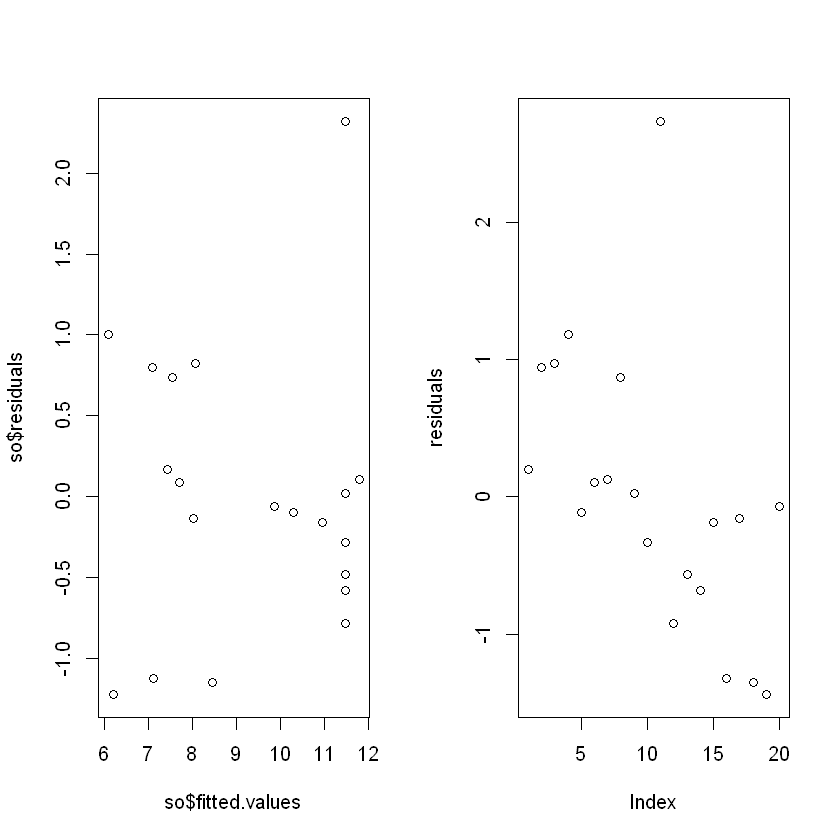

```r
par(mfrow = c(1, 2))
plot(so$fitted.values, so$residuals) # 적합값 vs 잔차 산점도
plot(scale(so$residuals), ylab = "residuals") # 표준화잔차
par(mfrow = c(1, 1))
```

- 표준화 잔차가 직선상에 어느 정도 놓이므로, 적합시킨 모형은 적합한 것으로 판단

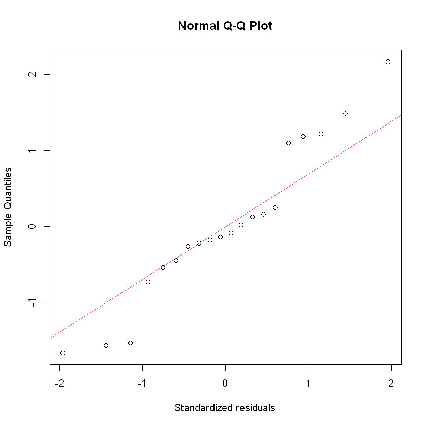

```r
residuals <- rstandard(so)
qqnorm(residuals, xlab = "Standardized residuals")
qqline(residuals, col = 2)
```

- 반응표면분석

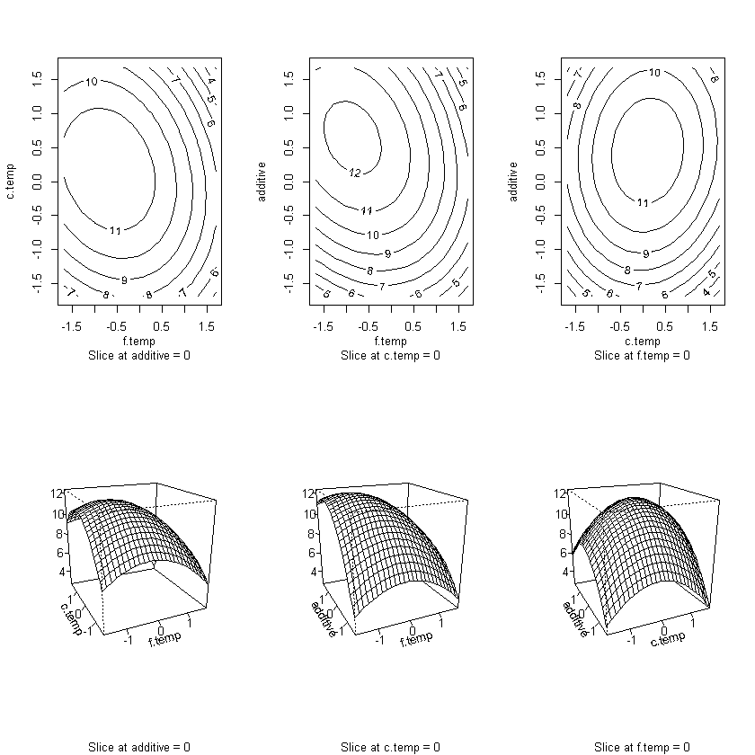

```r
par(mfrow = c(2, 3))
contour(so, ~ f.temp + c.temp + additive)
persp(so,  ~ f.temp + c.temp + additive)
```

- 적합한 모형으로부터의 최적수준
  - 적합시킨 모형을 목접함수로 두고, $x_1, x_2, x_3$에 대해 1차 편미분하여 0으로 두고 계산
  - 1차 편미분하여 0으로 둔 행렬식

  $$f(x_1, x_2, x_3) = 11.48, -1.14x_1 + 0.124x_2 + 1.082x_3 $$

$$-0.412x_1 x_2 - 0.563 x_1 x_3 + 0.213 x_2 x_3$$$$-0.862x_1^2-1.145 x^2_2-1.215x^2_3$$

$$ \frac{f} {\Delta x_1}=-1.14-0.412x_2-0.563 x_3 -2\times 0.862 x_1= 0\;\;\;\rightarrow\;\;\;-1.7236 x_1 -0.412 x_2 -0.563 x_3 = 1.14$$$$ \frac{f} {\Delta x_2}=0.124-0.412 x_1-0.213 x_3-2 \times 1.145 x_2= 0\;\;\;\rightarrow\;\;\;-0.412 x_1 -2.9 x_2 +0.213 x_3 = -0.124$$$$ \frac{f} {\Delta x_3}=1.082-0.563 x_1 + 0.213x_2 -2\times 1.215= 0\;\;\;\rightarrow\;\;\;-0.563 x_1 0.213 x_2 -2.43 x_3 = -1.082$$

이기에

```r
A = matrix(nrow = 3, c(-1.7236, -0.4125, -0.5625, -0.4125, -2.9, 0.2125, -0.5625, 0.2125, -2.43))
b = matrix(nrow = 3, c(1.14023, -0.12379, -1.08166))

opt = solve(A, b)
opt
```

A matrix: 3 × 1 of type dbl

| -0.9382593 |
| --- |
| 0.2261264 |
| 0.6820916 |

```r
opt * matrix(c(20, 5, 0.6)) + matrix(nrow = 3, c(120, 10, 1.1))
```

A matrix: 3 × 1 of type dbl

| 101.234815 |
| --- |
| 11.130632 |
| 1.509255 |

- 최적수준에서의 예측값

```r
predict(so, data.frame(f.temp = -0.938, c.temp = 0.226, additive = 0.682))
```

**1:** 12.4133878139747